# Demonstration: Plotting NHMS Finding

Kursus R: Pengenalan dan Praktikal (Sesi 4)

Mohd Azmi Bin Suliman

azmi.suliman@moh.gov.my

Pusat Penyelidikan Penyakit Tak Berjangkit, Institut Kesihatan Umum

Wednesday, 27 March 2024

# Demonstration: Plotting NHMS Finding

- Plot to Map
- Pyramid Plot

## Demonstration: Plotting NHMS Finding

- In this demonstration, I’ll show some example of data wrangling, including data joining, and plotting the finding to Malaysia Map
- The aim of this demonstration is to plot the Overall Hypercholesterolaemia prevalence by state to Malaysian map.

## Data Import

- We will use the NHMS 2019 dataset, as in previous slide.
- Import using `read_sav( )` function from `haven` package
- Remove missing value in outcome variable, i.e., `total_chol`
- Convert `total_chol` to numeric, i.e., `total_cholN`

```r
library(tidyverse)
library(haven)

nhms19ds <- read_sav("nhms19ds.sav") %>%
  as_factor() %>%
  filter(!is.na(total_chol)) %>%
  mutate(total_cholN = as.numeric(total_chol)-2,
         .after = total_chol)
```

## Specifying The Design

- This step is same with previous slide
- The first step in analyzing complex survey data is to specify the survey design
- I also add some option to adjust the lonely PSU

```r
library(survey)

options(survey.lonely.psu = 'adjust',
        survey.adjust.domain.lonely = TRUE)

nhms_surdsg <- svydesign(id = ~ebid,
                         strata = ~state_st,
                         weights = ~wtfinal_ncd,
                         data = nhms19ds,
                         nest = T)
```

## Subpopulation by State

- We have to estimate the prevalence of hypercholesterolaemia by state, using `svyby( )` function

```r
tcprev_state <- svyby(formula = ~total_cholN,
                      by = ~state,
                      design = nhms_surdsg,
                      FUN = svymean,
                      na.rm.all = T)

tcprev_state
```

```
                    state total_cholN         se
Johor               Johor   0.2888980 0.02981029
Kedah               Kedah   0.4891011 0.04250367
Kelantan         Kelantan   0.5109486 0.03325957
Melaka             Melaka   0.3973871 0.04483197
N. Sembilan   N. Sembilan   0.4828418 0.03612607
Pahang             Pahang   0.4032943 0.02715845
P. Pinang       P. Pinang   0.4184658 0.04222534
Perak               Perak   0.4621759 0.03729610
Perlis             Perlis   0.4715544 0.03942188
Selangor         Selangor   0.3573857 0.02555548
Terengganu     Terengganu   0.4092223 0.02769900
Sabah               Sabah   0.2987113 0.02340787
Sarawak           Sarawak   0.3591847 0.03018835
WP Kl               WP Kl   0.3644929 0.03894815
WP Labuan       WP Labuan   0.2957289 0.02124179
WP Putrajaya WP Putrajaya   0.4525309 0.03013872
```

## Download Malaysia Map

- Malaysian Map is available in DOSM github.
- In R, spatial analysis is done using `sf` package
- Instead of download the file, in this example, I’ll read directly the map (.geojson file) from the github

```r
library(sf)

dosm_my_map_link <- "https://raw.githubusercontent.com/dosm-malaysia/data-open/main/datasets/geodata/administrative_1_state.geojson"

read_sf(dosm_my_map_link)
```

## Download Malaysia Map

```r
library(sf)

dosm_my_map_link <- "https://raw.githubusercontent.com/dosm-malaysia/data-open/main/datasets/geodata/administrative_1_state.geojson"

read_sf(dosm_my_map_link)
```

```
Simple feature collection with 16 features and 2 fields
Geometry type: MULTIPOLYGON
Dimension:     XY
Bounding box:  xmin: 99.6409 ymin: 0.85539 xmax: 119.269 ymax: 7.36098
Geodetic CRS:  WGS 84
# A tibble: 16 × 3
   state             code_state                                         geometry
   <chr>                  <int>                               <MULTIPOLYGON [°]>
 1 Selangor                  10 (((101.7533 2.81998, 101.7612 2.70694, 101.7584…
 2 Pahang                     6 (((103.9788 2.70211, 103.9829 2.69667, 103.9878…
 3 Pulau Pinang               7 (((100.5371 5.2666, 100.5526 5.14372, 100.5428 …
 4 Sarawak                   13 (((110.7571 1.55217, 110.76 1.55647, 110.7624 1…
 5 Kedah                      2 (((100.7375 5.30512, 100.7382 5.30388, 100.7368…
 6 Perak                      8 (((100.7609 4.0423, 100.7644 4.05937, 100.7631 …
 7 Sabah                     12 (((118.6798 4.07375, 118.6824 4.07767, 118.6967…
 8 Kelantan                   3 (((101.8147 4.75934, 101.8052 4.75958, 101.8002…
 9 Negeri Sembilan            5 (((102.6248 2.62871, 102.6238 2.62517, 102.6261…
10 W.P. Kuala Lumpur         14 (((101.6672 3.24432, 101.6733 3.23577, 101.6723…
11 W.P. Labuan               15 (((115.1419 5.18637, 115.1408 5.18577, 115.1387…
12 Perlis                     9 (((100.2104 6.72068, 100.2145 6.71939, 100.2205…
13 Johor                      1 (((103.416 1.31868, 103.4153 1.33265, 103.4156 …
14 Melaka                     4 (((102.3322 2.04767, 102.3331 2.0491, 102.3347 …
15 Terengganu                11 (((103.4645 4.57023, 103.4676 4.56449, 103.4687…
16 W.P. Putrajaya            16 (((101.6985 2.97171, 101.6983 2.96828, 101.7018…
```

## Cleaning Map Dataset

- The state name from DOSM github and NHMS dataset is not consistent
- Short data wrangling is needed to ensure the state name is consistent

```r
my_state_sf <- read_sf(dosm_my_map_link) %>%
  arrange(code_state) %>%
  mutate(state = fct_recode(state,
                            "P. Pinang" = "Pulau Pinang",
                            "N. Sembilan" = "Negeri Sembilan",
                            "WP Kl" = "W.P. Kuala Lumpur",
                            "WP Putrajaya" = "W.P. Putrajaya",
                            "WP Labuan" = "W.P. Labuan"))
```

## Joining Map and Survey Data

- We can join the survey data with the map data using `left_join( )` function
  - The combine data frame need to convert to `sf` object using `st_as_sf( )` function

```r
tcprev_state_mapds <- left_join(tcprev_state, my_state_sf) %>%
  st_as_sf()

tcprev_state_mapds
```

```
Simple feature collection with 16 features and 4 fields
Geometry type: MULTIPOLYGON
Dimension:     XY
Bounding box:  xmin: 99.6409 ymin: 0.85539 xmax: 119.269 ymax: 7.36098
Geodetic CRS:  WGS 84
First 10 features:
         state total_cholN         se code_state                       geometry
1        Johor   0.2888980 0.02981029          1 MULTIPOLYGON (((103.416 1.3...
2        Kedah   0.4891011 0.04250367          2 MULTIPOLYGON (((100.7375 5....
3     Kelantan   0.5109486 0.03325957          3 MULTIPOLYGON (((101.8147 4....
4       Melaka   0.3973871 0.04483197          4 MULTIPOLYGON (((102.3322 2....
5  N. Sembilan   0.4828418 0.03612607          5 MULTIPOLYGON (((102.6248 2....
6       Pahang   0.4032943 0.02715845          6 MULTIPOLYGON (((103.9788 2....
7    P. Pinang   0.4184658 0.04222534          7 MULTIPOLYGON (((100.5371 5....
8        Perak   0.4621759 0.03729610          8 MULTIPOLYGON (((100.7609 4....
9       Perlis   0.4715544 0.03942188          9 MULTIPOLYGON (((100.2104 6....
10    Selangor   0.3573857 0.02555548         10 MULTIPOLYGON (((101.7533 2....
```

## Plotting The Map

- Plotting the map is simple using `ggplot( )` function

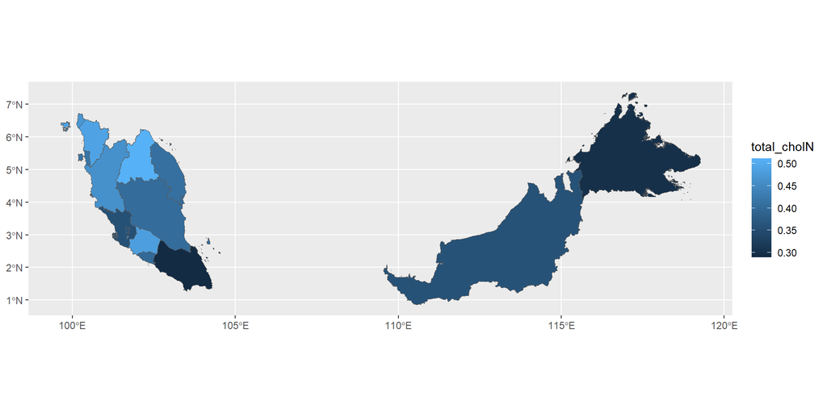

```r
tcprev_state_mapds %>%
  ggplot(aes(fill = total_cholN)) +
  geom_sf()
```

# Pyramid Plot

## Pyramid Plot

- Also known as population pyramid
- Graphical presentation to visualize the age and gender distribution of population
- NHMS commonly use Pyramid Plot to compare the sample representation with the national population
- In this example, we will compare NHMS 2019 with DOSM population.

## Pyramid Plot

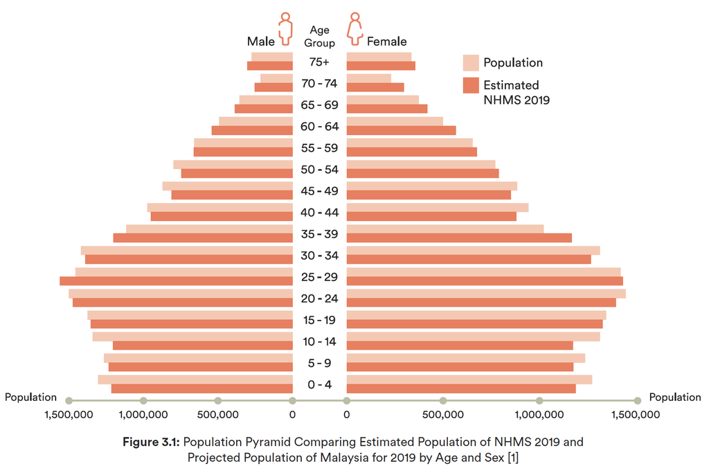

## Pyramid Plot (Preparation)

- When comparing NHMS with DOSM, we need to ensure that the data is compatible.
- In our pyramid plot, only two variable needed, which is **Age** and **Gender**
- Let’s take a look at our dataset.

```r
nhms19ds
```

```
# A tibble: 10,466 × 41
   state strata_gp A2101  A2104 A2104_grp A2106_5grp A2107 A2108_3grp A2109_4grp
   <fct> <fct>     <fct>  <dbl> <fct>     <fct>      <fct> <fct>      <fct>
 1 Johor Urban     Male      67 65-69     Chinese    Mala… Married    Primary e…
 2 Johor Urban     Male      39 35-39     Malay      Mala… Married    Secondary…
 3 Johor Urban     Female    41 40-44     Malay      Mala… Married    Secondary…
 4 Johor Urban     Male      36 35-39     Malay      Mala… Married    Secondary…
 5 Johor Urban     Female    32 30-34     Malay      Mala… Married    Secondary…
 6 Johor Urban     Male      69 65-69     Malay      Mala… Married    Primary e…
 7 Johor Urban     Female    65 65-69     Malay      Mala… Married    No formal…
 8 Johor Urban     Female    68 65-69     Malay      Mala… Widow(er)… Secondary…
 9 Johor Urban     Male      21 20-24     Malay      Mala… SIngle     Secondary…
10 Johor Urban     Female    63 60-64     Malay      Mala… Married    Secondary…
# ℹ 10,456 more rows
# ℹ 32 more variables: A2221 <fct>, A2222_7grp <fct>, A2222_5grp <fct>,
#   indvid <chr>, hh_id <chr>, state_st <dbl>, ebid <chr>, wtfinal_ncd <dbl>,
#   c01 <fct>, c02 <fct>, c03 <fct>, c03a <fct>, c04a <fct>, c04b <fct>,
#   c04c <fct>, c04d <fct>, c05 <fct>, c06 <fct>, u303 <fct>, known_chol <fct>,
#   undiagnosed_chol <fct>, total_chol <fct>, total_cholN <dbl>,
#   bodyweight1 <fct>, bodyweight2 <fct>, bodyheight1 <fct>, …
```

## Pyramid Plot (Preparation)

- When comparing NHMS with DOSM, we need to ensure that the data is compatible.
- Let’s take a look at our dataset.
  - In our dataset, we have both Age (`A2104_grp`) and Gender (`A2101`)

```r
nhms19ds %>%
  select(A2104_grp, A2101) %>%
  freq()
```

## Pyramid Plot (Preparation)

```
Frequencies
nhms19ds$A2104_grp
Label: [Final] Age Group - 16 groups
Type: Factor

               Freq   % Valid   % Valid Cum.   % Total   % Total Cum.
----------- ------- --------- -------------- --------- --------------
      15-19     334      3.19           3.19      3.19           3.19
      20-24     938      8.96          12.15      8.96          12.15
      25-29     973      9.30          21.45      9.30          21.45
      30-34    1008      9.63          31.08      9.63          31.08
      35-39    1065     10.18          41.26     10.18          41.26
      40-44     890      8.50          49.76      8.50          49.76
      45-49     908      8.68          58.44      8.68          58.44
      50-54     957      9.14          67.58      9.14          67.58
      55-59     940      8.98          76.56      8.98          76.56
      60-64     838      8.01          84.57      8.01          84.57
      65-69     645      6.16          90.73      6.16          90.73
      70-74     455      4.35          95.08      4.35          95.08
        75+     515      4.92         100.00      4.92         100.00
       <NA>       0                               0.00         100.00
      Total   10466    100.00         100.00    100.00         100.00

nhms19ds$A2101
Label: [Final] Gender
Type: Factor

                Freq   % Valid   % Valid Cum.   % Total   % Total Cum.
------------ ------- --------- -------------- --------- --------------
        Male    4784     45.71          45.71     45.71          45.71
      Female    5682     54.29         100.00     54.29         100.00
        <NA>       0                               0.00         100.00
       Total   10466    100.00         100.00    100.00         100.00
```

## Pyramid Plot (DOSM)

- DOSM provide population data by age.
- We can refer their OpenDOSM data repository
  - https://open.dosm.gov.my/data-catalogue/population_malaysia
- We can download the dataset

```r
dosmpopds0 <- read_csv("https://storage.dosm.gov.my/population/population_malaysia.csv")

dosmpopds0
```

```
# A tibble: 13,167 × 6
   date       state    sex         age         ethnicity         population
   <date>     <chr>    <chr>       <chr>       <chr>                  <dbl>
 1 1991-01-01 Malaysia overall_sex overall_age overall_ethnicity    18547.
 2 1991-01-01 Malaysia female      80-84       bumi_malay              17.9
 3 1991-01-01 Malaysia female      75-79       other_noncitizen         1.1
 4 1991-01-01 Malaysia female      75-79       other_citizen            0.5
 5 1991-01-01 Malaysia female      75-79       indian                   3.4
 6 1991-01-01 Malaysia female      75-79       chinese                 27.1
 7 1991-01-01 Malaysia female      75-79       bumi_other               3.7
 8 1991-01-01 Malaysia female      75-79       bumi_malay              20.4
 9 1991-01-01 Malaysia female      70-74       other_noncitizen         1.9
10 1991-01-01 Malaysia female      70-74       other_citizen            0.9
# ℹ 13,157 more rows
```

## Pyramid Plot (DOSM)

- Examining the DOSM dataset show that both required variable are available.
- We can wrangle the dataset appropriately
  - Filter only to year `2019`
  - Exclude `overall_sex` (or include only `male` and `female`)
  - Filter only to `overall_ethnicity`
  - Exclude `overall_age`

```r
dosmpopds <- dosmpopds0 %>%
  filter(date == "2019-01-01",
         sex != "overall_sex",
         ethnicity == "overall_ethnicity",
         age != "overall_age")
```

## Pyramid Plot (DOSM)

```r
dosmpopds
```

```
# A tibble: 36 × 6
   date       state    sex    age   ethnicity         population
   <date>     <chr>    <chr>  <chr> <chr>                  <dbl>
 1 2019-01-01 Malaysia female 55-59 overall_ethnicity      708.
 2 2019-01-01 Malaysia female 60-64 overall_ethnicity      586.
 3 2019-01-01 Malaysia female 65-69 overall_ethnicity      442.
 4 2019-01-01 Malaysia female 70-74 overall_ethnicity      318.
 5 2019-01-01 Malaysia female 75-79 overall_ethnicity      184.
 6 2019-01-01 Malaysia female 80-84 overall_ethnicity      113.
 7 2019-01-01 Malaysia female 85+   overall_ethnicity       75.2
 8 2019-01-01 Malaysia male   0-4   overall_ethnicity     1331.
 9 2019-01-01 Malaysia male   10-14 overall_ethnicity     1299.
10 2019-01-01 Malaysia male   15-19 overall_ethnicity     1480.
# ℹ 26 more rows
```

## Pyramid Plot (DOSM)

- Examining the DOSM dataset show that both required variable are available.
- Further transformation require to ensure compability
  - Rename `sex` to `A2101`
  - recode gender to `Male` and `Female`
  - Rename `age` to `A2104_grp`
  - Filter and collapse age group to match NHMS

```r
dosmpopds %>%
  select(sex, age) %>%
  freq()
```

## Pyramid Plot (DOSM)

```r
dosmpopds %>%
  select(sex, age) %>%
  freq()
```

```
Frequencies
dosmpopds$sex
Type: Character

               Freq   % Valid   % Valid Cum.   % Total   % Total Cum.
------------ ------ --------- -------------- --------- --------------
      female     18     50.00          50.00     50.00          50.00
        male     18     50.00         100.00     50.00         100.00
        <NA>      0                               0.00         100.00
       Total     36    100.00         100.00    100.00         100.00

dosmpopds$age
Type: Character

              Freq   % Valid   % Valid Cum.   % Total   % Total Cum.
----------- ------ --------- -------------- --------- --------------
        0-4      2      5.56           5.56      5.56           5.56
      10-14      2      5.56          11.11      5.56          11.11
      15-19      2      5.56          16.67      5.56          16.67
      20-24      2      5.56          22.22      5.56          22.22
      25-29      2      5.56          27.78      5.56          27.78
      30-34      2      5.56          33.33      5.56          33.33
      35-39      2      5.56          38.89      5.56          38.89
      40-44      2      5.56          44.44      5.56          44.44
      45-49      2      5.56          50.00      5.56          50.00
        5-9      2      5.56          55.56      5.56          55.56
      50-54      2      5.56          61.11      5.56          61.11
      55-59      2      5.56          66.67      5.56          66.67
      60-64      2      5.56          72.22      5.56          72.22
      65-69      2      5.56          77.78      5.56          77.78
      70-74      2      5.56          83.33      5.56          83.33
      75-79      2      5.56          88.89      5.56          88.89
      80-84      2      5.56          94.44      5.56          94.44
        85+      2      5.56         100.00      5.56         100.00
       <NA>      0                               0.00         100.00
      Total     36    100.00         100.00    100.00         100.00
```

## Pyramid Plot (DOSM)

- Examining the DOSM dataset show that both required variable are available.
- Further transformation require to ensure compability
  - Rename `sex` to `A2101`
  - recode gender to `Male` and `Female`
  - Rename `age` to `A2104_grp`
  - *Collapse* age group
  - Add `source` (`dosm`)

## Pyramid Plot (DOSM)

```r
dosmpopds <- dosmpopds %>%
  mutate(A2101 = fct_recode(sex,
                            "Male" = "male",
                            "Female" = "female"),
         A2104_grp = fct_collapse(age,
                              "0-14" = c("0-4", "5-9", "10-14"),
                              "75+" = c("75-79", "80-84", "85+")),
         source = "dosm") %>%
  group_by(A2104_grp, A2101, source) %>%
  summarise(population = sum(population)*1000) %>%
  ungroup() %>%
  filter(A2104_grp != "0-14")
```

## Pyramid Plot (DOSM)

- Examining the DOSM dataset show that both required variable are available.

```r
dosmpopds
```

```
# A tibble: 26 × 4
   A2104_grp A2101  source population
   <fct>     <fct>  <chr>       <dbl>
 1 15-19     Female dosm      1377400
 2 15-19     Male   dosm      1480100
 3 20-24     Female dosm      1505200
 4 20-24     Male   dosm      1675900
 5 25-29     Female dosm      1524400
 6 25-29     Male   dosm      1746200
 7 30-34     Female dosm      1367700
 8 30-34     Male   dosm      1502400
 9 35-39     Female dosm      1208800
10 35-39     Male   dosm      1304000
# ℹ 16 more rows
```

## Pyramid Plot (NHMS Estimated Population)

- Our NHMS dataset already have weightage calculated, which post-stratification to the national population, by state, gender and ethnicity.
- Using the weightage design, we can estimated total population.
- In our nhms dataset, we need to count all sample.
  - Let create new variable and put value `1` for all sample.

```r
nhms19ds <- nhms19ds %>%
  mutate(cholall = 1,
         .before = 1)

nhms19ds
```

## Pyramid Plot (NHMS Estimated Population)

```r
nhms19ds <- nhms19ds %>% mutate(cholall = 1, .before = 1)
nhms19ds
```

```
# A tibble: 10,466 × 42
   cholall state strata_gp A2101  A2104 A2104_grp A2106_5grp A2107    A2108_3grp
     <dbl> <fct> <fct>     <fct>  <dbl> <fct>     <fct>      <fct>    <fct>
 1       1 Johor Urban     Male      67 65-69     Chinese    Malaysi… Married
 2       1 Johor Urban     Male      39 35-39     Malay      Malaysi… Married
 3       1 Johor Urban     Female    41 40-44     Malay      Malaysi… Married
 4       1 Johor Urban     Male      36 35-39     Malay      Malaysi… Married
 5       1 Johor Urban     Female    32 30-34     Malay      Malaysi… Married
 6       1 Johor Urban     Male      69 65-69     Malay      Malaysi… Married
 7       1 Johor Urban     Female    65 65-69     Malay      Malaysi… Married
 8       1 Johor Urban     Female    68 65-69     Malay      Malaysi… Widow(er)…
 9       1 Johor Urban     Male      21 20-24     Malay      Malaysi… SIngle
10       1 Johor Urban     Female    63 60-64     Malay      Malaysi… Married
# ℹ 10,456 more rows
# ℹ 33 more variables: A2109_4grp <fct>, A2221 <fct>, A2222_7grp <fct>,
#   A2222_5grp <fct>, indvid <chr>, hh_id <chr>, state_st <dbl>, ebid <chr>,
#   wtfinal_ncd <dbl>, c01 <fct>, c02 <fct>, c03 <fct>, c03a <fct>, c04a <fct>,
#   c04b <fct>, c04c <fct>, c04d <fct>, c05 <fct>, c06 <fct>, u303 <fct>,
#   known_chol <fct>, undiagnosed_chol <fct>, total_chol <fct>,
#   total_cholN <dbl>, bodyweight1 <fct>, bodyweight2 <fct>, …
```

## Pyramid Plot (NHMS Estimated Population)

- Our NHMS dataset already have weightage calculated, which post-stratification to the national population, by state, gender and ethnicity.
- Using the weightage design, we can estimated total population.
- We need to create new sampling design plan

```r
nhms_surdsg <- svydesign(id = ~ebid,
                         strata = ~state_st,
                         weights = ~wtfinal_ncd,
                         data = nhms19ds,
                         nest = T)
```

## Pyramid Plot (NHMS Estimated Population)

- Our NHMS dataset already have weightage calculated, which post-stratification to the national population, by state, gender and ethnicity.
- Using the weightage design, we can estimated total population.

```r
nhmspopds <- svyby(formula = ~cholall,
                   by = ~ A2101 + A2104_grp,
                   design = nhms_surdsg,
                   FUN = svytotal) %>%
  as_tibble() %>%
  select(-se, population = cholall) %>%
  mutate(source = "nhms")
```

## Pyramid Plot (NHMS Estimated Population)

- Our NHMS dataset already have weightage calculated, which post-stratification to the national population, by state, gender and ethnicity.
- Using the weightage design, we can estimated total population.

```r
nhmspopds
```

```
# A tibble: 26 × 4
   A2101  A2104_grp population source
   <fct>  <fct>          <dbl> <chr>
 1 Male   15-19        497478. nhms
 2 Female 15-19        394575. nhms
 3 Male   20-24       1496318. nhms
 4 Female 20-24       1375431. nhms
 5 Male   25-29       1585427. nhms
 6 Female 25-29       1410589. nhms
 7 Male   30-34       1412422. nhms
 8 Female 30-34       1248302. nhms
 9 Male   35-39       1221228. nhms
10 Female 35-39       1149626. nhms
# ℹ 16 more rows
```

## Pyramid Plot (Combine Dataset)

- Using `full_join( )` function, we can combine both dataset

```r
populationds <- full_join(dosmpopds, nhmspopds)

populationds
```

```
# A tibble: 52 × 4
   A2104_grp A2101  source population
   <fct>     <fct>  <chr>       <dbl>
 1 15-19     Female dosm      1377400
 2 15-19     Male   dosm      1480100
 3 20-24     Female dosm      1505200
 4 20-24     Male   dosm      1675900
 5 25-29     Female dosm      1524400
 6 25-29     Male   dosm      1746200
 7 30-34     Female dosm      1367700
 8 30-34     Male   dosm      1502400
 9 35-39     Female dosm      1208800
10 35-39     Male   dosm      1304000
# ℹ 42 more rows
```

## Build Pyramid Plot

- Using `ggplot( )` function, we can build the pyramid plot
- Since we want the female is on left side, we need to wrangle a bit.

```r
populationds <- populationds %>%
  mutate(population = if_else(A2101 == "Female", 0-population, population))

populationds %>%
  ggplot(aes(x = A2104_grp, y = population, fill = interaction(A2101, source))) +
  geom_col(position = "dodge") +
  scale_y_continuous(expand = c(0, 0), name = "Population",
                      labels = function(x) scales::comma(abs(x))) +
  labs(x = "Age Group") +
  scale_fill_manual(values = hcl(h = c(15, 195, 15, 195),
                                 c = 100,
                                 l = 65,
                                 alpha = c(.4, .4, 1, 1)),
                    name = "") +
  coord_flip() +
  facet_wrap(. ~ A2101, scales = "free_x", strip.position = "bottom") +
  theme_bw() +
  theme(panel.border = element_blank(),
        axis.ticks.y = element_blank(),
        panel.grid.major.y = element_blank(),
        legend.position = "bottom",
        panel.spacing.x = unit(0, "pt"),
        strip.background = element_rect(colour = "black"))
```

## Build Pyramid Plot

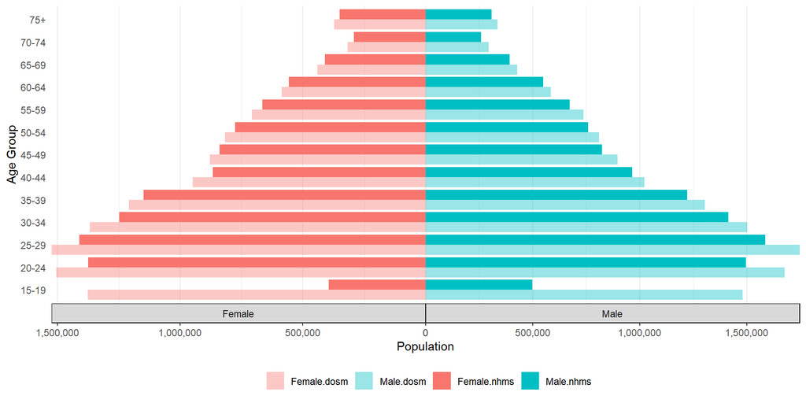

Complex Sampling Design